# Microbial Response to Rainfall – Geochemistry and 16S Analysis

Authors: [Karl J. Romanowicz](https://lsa.umich.edu/eeb/people/graduate-students/kjromano.html), Byron C. Crump, George W. Kling

**R Notebook:** Provides reproducible analysis for geochemistry and 16S rRNA data in the following manuscript:

**Citation:** Romanowicz, KJ, Crump, BC, Kling, GW. (2021) Rainfall alters permafrost soil redox conditions, but meta-omics show divergent microbial community responses by tundra type in the arctic. Soil Systems 5(1): 17. https://doi.org/10.3390/soilsystems5010017

**GitHub Repository:** https://github.com/kromanowicz/2021-Romanowicz-SoilSystems

**NCBI BioProject:** https://www.ncbi.nlm.nih.gov/bioproject/PRJNA666429

**Accepted for Publication:** *Soil Systems* 10 March 2021

# Experiment

This R Notebook provides complete reproducibility of the data analysis in *“Rainfall alters permafrost soil redox conditions, but meta-omics show divergent microbial community responses by tundra type in the Arctic”* by Romanowicz, Crump, and Kling. In this experiment, mesocosms containing soil from the active layer of two dominant tundra types were subjected to simulated rainfall to alter redox conditions. The microbial functional potential (metagenomics) and gene expression (metatranscriptomics) patterns were measured during saturated anoxic redox conditions prior to rainfall and at multiple time points following the simulated rainfall event. Other measurements include soil properties as well as microbial respiration (CO<sub>2</sub>) and methane (CH<sub>4</sub>) production from soil subsamples collected at each sampling time point. The purpose was to determine if rainfall, as a form of soil oxidation, is sufficient to alter the anoxic redox conditions in arctic tundra and enhance the microbial degradation of organic carbon and CH<sub>4</sub> to CO<sub>2</sub>.

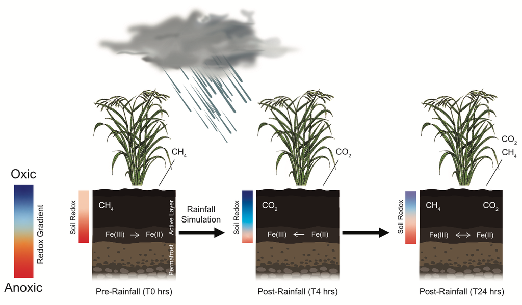

**Conceptual Figure.** A total of 12 tundra mesocosms (3 replicates x 2 tundra types x 2 sets of response cores) were acclimated initially under anoxic redox conditions to mimic field conditions (T0). Dissolved oxygen was supplied to soils through the downward flow of oxygenated water during a simulated rainfall event. Dissolved oxygen will likely change the redox gradient directly following rainfall (T4) as a short-term effect. Anoxic conditions will likely be re-established after 24 hours (T24) as the pulse of oxygen is consumed through abiotic and biotic soil processes. Under anoxic redox conditions (T0), microorganisms likely degrade organic carbon through anaerobic and fermentation pathways, producing CH<sub>4</sub> and reducing Fe(III) to Fe(II). Rainfall-induced soil oxidation (T4) should stimulate heterotrophic microorganisms that degrade organic carbon and CH<sub>4</sub> through aerobic metabolic pathways, releasing CO<sub>2</sub>. Soil oxidation should also stimulate aerobic autotrophic iron oxidizing bacteria that oxidize Fe(II) to Fe(III) and convert CO<sub>2</sub> into microbial biomass. The long-term response (T24) will likely be a combination of aerobic and anaerobic metabolism as well as a combination of reduction and oxidation iron reactions as dissolved oxygen is consumed. The predicted redox conditions and predicted redox reactions for coupled Fe(II)/Fe(III) cycling, as well as the microbial-induced release of CO<sub>2</sub> or CH<sub>4</sub> at each time point are based on the predicted availability of dissolved oxygen entering tundra soils through simulated rainfall.

**Soil Sampling for Microbial Gene Expression**

An initial soil sampling event for microbial activity was conducted at the end of the anoxic acclimation period (4-7 days) in all mesocosm replicates, representing sampling time point **T0**. Mesocosms were then flushed to simulate a rainfall event. Additional soil sampling events were conducted at **T4** (4-hrs) and **T24** (24-hrs) following the rainfall event to determine the temporal extent of microbial gene expression. Soil cores (2.54 cm diameter, 30 cm length) were extracted in duplicate from each mesocosm replicate at each sampling time point and homogenized by depth in 10-cm increments. The 10-20 cm soil increment, composed of organic soil in all mesocosm replicates, was chosen for microbial gene expression analysis and preserved in RNAlater Stabilization Reagent in sterile tubes at 4°C for 18 hours and then stored at -80°C until extraction.

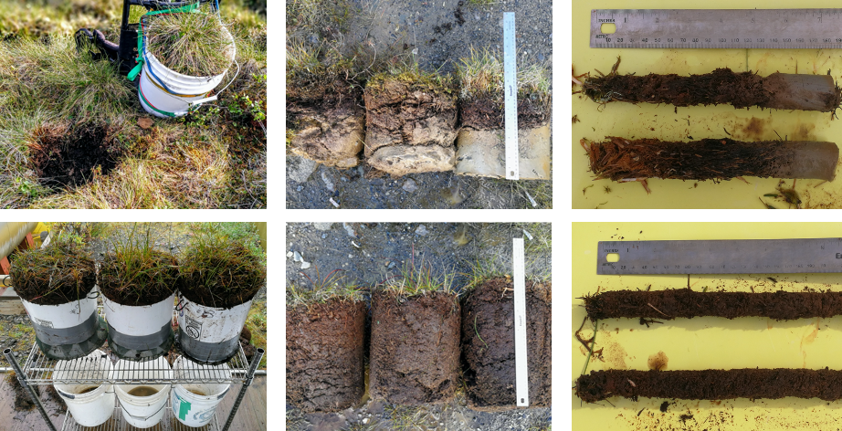

**Field Experiment.** Tundra soil cores were collected from field sites in August 2017 (top left) and placed in buckets to establish the mesocosm experiment (bottom left). Tussock tundra cores were composed of an organic soil layer overlying a mineral soil layer (top middle) while wet sedge tundra cores were composed entirely of organic soil (bottom middle). Soil subsampling for microbial activity was taken from the 10-20 cm depth of duplicate soil cores in Tussock (top right) and Wet Sedge (bottom right).

```r
# Make a vector of required packages
required.packages <- c("ape","cowplot","data.table","devtools","dplyr","DT","ggplot2","ggpubr","gridExtra","kableExtra","knitr","pheatmap","png","RColorBrewer","reshape","rstatix","statmod","stringr","tibble","tidyr","tidyverse","vegan","yaml")

# Load required packages
lapply(required.packages, library, character.only = TRUE)
```

# Geochemistry

Properties of bulk soil cores from tussock tundra and wet sedge tundra mesocosms measured at the end of the anoxic acclimation period (mean (SD), N=6). Soil moisture was quantified as the volumetric water content of the soils.

| Variable | Tussock.Tundra | Wet.Sedge.Tundra |
| --- | --- | --- |
| pH | 4.6 (0.4) | 6.1 (0.1) |
| Conductivity (uS/cm) | 66 (19) | 124 (14) |
| Moisture (% water) | 63 (8) | 70 (4) |
| Temperature (C at 15 cm) | 7.8 (0.3) | 8.5 (0.3) |
| Organic carbon content (%) | 33.8 (4.3) | 40.3 (2.3) |
| Bulk density (g soil/cm3) | 0.53 (0.10) | 0.27 (0.04) |
| Porosity (% soil volume) | 63.3 (6.6) | 81.3 (2.6) |
| DI Water flushed (L) | 20 (0) | 20 (0) |
| Duration of DI flush (hr) | 3.77 (0.42) | 1.13 (0.19) |

Run pairwise comparisons between tundra ecosystems for each geochemical characteristic to determine significance.

```r
soil.chem.t.test.stats <- soil.chem.t.test %>%
  group_by(Chemistry) %>%
  pairwise_t_test(
    Value ~ Tundra, paired = TRUE,
    ) %>%
  select(-.y., -n1, -n2, -df, -statistic, -p) # Remove details
soil.chem.t.test.stats
```

| Chemistry | group1 | group2 | p.adj | p.adj.signif |
| --- | --- | --- | --- | --- |
| BD | Tuss | WS | 0.022 | * |
| Conductivity | Tuss | WS | 0.049 | * |
| Flush.Time | Tuss | WS | 0.017 | * |
| Moisture | Tuss | WS | 0.093 | ns |
| O2.Accum | Tuss | WS | 0.008 | ** |
| O2.Consume | Tuss | WS | 0.025 | * |
| O2.End.Flush | Tuss | WS | 0.022 | * |
| O2.T0 | Tuss | WS | 0.274 | ns |
| O2.T24 | Tuss | WS | 0.031 | * |
| O2.T4 | Tuss | WS | 0.023 | * |

[output cut: 6 more lines]

# 16S Amplicons

## 2. 16S Bioinformatics

### 2.1. Raw Reads

*Prep the Raw Reads*

Transfer all paired .FASTQ files to a working directory in the Advanced Research Computing Great Lakes Cluster (ARC-GLC) at the University of Michigan. Load the MOTHUR module to begin processing the raw sequencing reads.

```markdown
{Terminal}
cd /2017_Redox/16S_Mothur
module load mothur/1.43.0
mothur
```

*Create Stability File*

Create a stability file in the FASTQ directory using the mothur command `make.file`. The first column is the name of the sample. The second column is the name of the forward read for that sample and the third column is the name of the reverse read for that sample.

```markdown
{Mothur}
make.file(inputdir=FASTQ)

### Output
Setting input directory to: FASTQ/

Output File Names:
FASTQ/stability.files
```

*Reducing Sequencing and PCR Errors*

The first step is to combine the two sets of reads for each sample and then combine the data from all of the samples. Use the `make.contigs` command, which requires the **stability.files** as input. This command extracts the sequence and quality score data from the fastq files, creates the reverse complement of the reverse read and then joins the reads into contigs.

```markdown
{Mothur}
make.contigs(file=stability.files)

### Output
Group count:
NegCTRL 41
PosCTRL 9832
TussT0Rep1  17781
TussT0Rep2  19061
TussT0Rep3  19203
TussT24Rep1 18430
TussT24Rep2 20757
TussT24Rep3 15982
TussT4Rep1  34830
TussT4Rep2  18128
TussT4Rep3  18654
WST0Rep1    29954
WST0Rep2    17977
WST0Rep3    17744
WST24Rep1   16938
WST24Rep2   17368
WST24Rep3   14282
WST4Rep1    13252
WST4Rep2    12291
WST4Rep3    16807

Total of all groups is 349312

It took 38 secs to process 349312 sequences.

Output File Names:
FASTQ/stability.trim.contigs.fasta
FASTQ/stability.scrap.contigs.fasta
FASTQ/stability.contigs.report
FASTQ/stability.contigs.groups
```

The output files **stability.trim.contigs.fasta** and **stability.contigs.groups** contain the sequence data and group identity for each sequence for downstream use.

*Initial Sequence Read Summary*

See what the sequences look like using the `summary.seqs` command:

```markdown
{Mothur}
summary.seqs(fasta=FASTQ/stability.trim.contigs.fasta)

### Output
        Start   End NBases  Ambigs  Polymer NumSeqs
Minimum:    1   248 248 0   3   1
2.5%-tile:  1   253 253 0   3   8733
25%-tile:   1   253 253 0   4   87329
Median:     1   253 253 0   5   174657
75%-tile:   1   253 253 0   5   261985
97.5%-tile: 1   254 254 5   6   340580
Maximum:    1   502 502 84  220 349312
Mean:   1   253 253 0   4
# of Seqs:  349312

It took 3 secs to summarize 349312 sequences.

Output File Names:
FASTQ/stability.trim.contigs.summary
```

This tells us that we have 349,312 sequences that mostly vary between 248 and 254 bases. The longest read in the dataset is 502 bp, which will be removed in subsequent steps because all reads are supposed to be 251 bp based on the Illumina MiSeq sequencing platform.

*Screen Sequencing Reads*

Run the command `screen.seqs` to remove poor-quality reads or those with ambiguous base calls. This command removes any sequences longer than 275 bp.

```markdown
{Mothur}
screen.seqs(fasta=FASTQ/stability.trim.contigs.fasta, group=FASTQ/stability.contigs.groups, summary=FASTQ/stability.trim.contigs.summary, maxambig=0, maxlength=275)

### Output
It took 2 secs to screen 349312 sequences, removed 41614.

/******************************************/
Running command: remove.seqs(accnos=FASTQ/stability.trim.contigs.bad.accnos.temp, group=FASTQ/stability.contigs.groups)
Removed 41614 sequences from your group file.

Output File Names:
FASTQ/stability.contigs.pick.groups

/******************************************/

Output File Names:
FASTQ/stability.trim.contigs.good.summary
FASTQ/stability.trim.contigs.good.fasta
FASTQ/stability.trim.contigs.bad.accnos
FASTQ/stability.contigs.good.groups


It took 6 secs to screen 349312 sequences.
```

*Processing Improved Sequences*

Here, we retain only a unique copy of each seqeunce to reduce computational resources using the `unique.seqs` command because many of our sequences are likely duplicates of each other. If two sequences have the same identical sequence then they are considered duplicates and are merged.

```markdown
{Mothur}
unique.seqs(fasta=FASTQ/stability.trim.contigs.good.fasta)

### Output
307698  81316

Output File Names:
FASTQ/stability.trim.contigs.good.names
FASTQ/stability.trim.contigs.good.unique.fasta
```

After running `unique.seqs`, we’ve gone from 307,698 to 81,316 sequences.

*Simplify Name and Group Files*

Run `count.seqs` command to generate a table where the rows are the names of the unique sequences and the columns are the names of the groups. The table is then filled with the number of times each unique sequence shows up in each group.

```markdown
{Mothur}
count.seqs(name=FASTQ/stability.trim.contigs.good.names, group=FASTQ/stability.contigs.good.groups)

### Output
It took 2 secs to create a table for 307698 sequences.

Total number of sequences: 307698

Output File Names:
FASTQ/stability.trim.contigs.good.count_table
```

*Re-summarize Sequence Reads*

Run the `summary.seqs` command again to see improvements in sequence read quality.

```markdown
{Mothur}
summary.seqs(count=FASTQ/stability.trim.contigs.good.count_table)

### Output
        Start   End NBases  Ambigs  Polymer NumSeqs
Minimum:    1   251 251 0   3   1
2.5%-tile:  1   253 253 0   3   7693
25%-tile:   1   253 253 0   4   76925
Median:     1   253 253 0   5   153850
75%-tile:   1   253 253 0   5   230774
97.5%-tile: 1   254 254 0   6   300006
Maximum:    1   275 275 0   10  307698
Mean:   1   253 253 0   4
# of unique seqs:   81316
total # of seqs:    307698

It took 1 secs to summarize 307698 sequences.

Output File Names:
FASTQ/stability.trim.contigs.good.unique.summary
```

*Align Sequences to Reference Alignment*

Use the SILVA reference file for sequence alignment (v.132), which can be downloaded as a [Full-length sequences and taxonomy references](https://mothur.s3.us-east-2.amazonaws.com/wiki/silva.nr_v132.tgz). This file contains 188,247 bacteria, 4,626 archaea, and 20,246 eukarya sequences. This step is RAM-intensive and requires additional computational resources beyond a GLC login-node capacity.

```markdown
{Mothur}
align.seqs(fasta=FASTQ/stability.trim.contigs.good.unique.fasta, reference=silva.nr_v132/silva.nr_v132.align)

### Output
It took 386 secs to align 81316 sequences.

[WARNING]: 4 of your sequences generated alignments that eliminated too many bases, a list is provided in FASTQ/stability.trim.contigs.good.unique.flip.accnos.
[NOTE]: 1 of your sequences were reversed to produce a better alignment.

It took 389 seconds to align 81316 sequences.

Output File Names:
FASTQ/stability.trim.contigs.good.unique.align
FASTQ/stability.trim.contigs.good.unique.align.report
FASTQ/stability.trim.contigs.good.unique.flip.accnos
```

*Summarize Aligned Sequence Reads*

Run the `summary.seqs` command again to see the alignment results for all sequence reads.

```markdown
{Mothur}
summary.seqs(fasta=FASTQ/stability.trim.contigs.good.unique.align, count=FASTQ/stability.trim.contigs.good.count_table)

### Output
        Start   End NBases  Ambigs  Polymer NumSeqs
Minimum:    1046    1056    3   0   1   1
2.5%-tile:  13862   23444   253 0   3   7693
25%-tile:   13862   23444   253 0   4   76925
Median:     13862   23444   253 0   5   153850
75%-tile:   13862   23444   253 0   5   230774
97.5%-tile: 13862   23444   254 0   6   300006
Maximum:    43113   43116   275 0   10  307698
Mean:   13862   23444   253 0   4
# of unique seqs:   81316
total # of seqs:    307698

It took 25 secs to summarize 307698 sequences.

Output File Names:
FASTQ/stability.trim.contigs.good.unique.summary
```

*Re-Run Sequence Screen*

To make sure all sequences overlap the same region we re-run `screen.seqs` command to get sequences that start at or before position 13,862 and end at or after position 23,444. We also set the maximum homopolymer length to 8 since there’s nothing in the database with a stretch of 9 or more of the same base in a row.

```markdown
{Mothur}
screen.seqs(fasta=FASTQ/stability.trim.contigs.good.unique.align, count=FASTQ/stability.trim.contigs.good.count_table, summary=FASTQ/stability.trim.contigs.good.unique.summary, start=13862, end=23444, maxhomop=8)

### Output
It took 24 secs to screen 81316 sequences, removed 203.

/******************************************/
Running command: remove.seqs(accnos=FASTQ/stability.trim.contigs.good.unique.bad.accnos.temp, count=FASTQ/stability.trim.contigs.good.count_table)
Removed 292 sequences from your count file.

Output File Names:
FASTQ/stability.trim.contigs.good.pick.count_table

/******************************************/

Output File Names:
FASTQ/stability.trim.contigs.good.unique.good.summary
FASTQ/stability.trim.contigs.good.unique.good.align
FASTQ/stability.trim.contigs.good.unique.bad.accnos
FASTQ/stability.trim.contigs.good.good.count_table


It took 26 secs to screen 81316 sequences.
```

```markdown
{Mothur}
summary.seqs(fasta=current, count=current)

### Output
        Start   End NBases  Ambigs  Polymer NumSeqs
Minimum:    10289   23444   251 0   3   1
2.5%-tile:  13862   23444   253 0   3   7686
25%-tile:   13862   23444   253 0   4   76852
Median:     13862   23444   253 0   5   153704
75%-tile:   13862   23444   253 0   5   230555
97.5%-tile: 13862   23444   254 0   6   299721
Maximum:    13862   26160   275 0   8   307406
Mean:   13861   23444   253 0   4
# of unique seqs:   81113
total # of seqs:    307406

It took 24 secs to summarize 307406 sequences.

Output File Names:
FASTQ/stability.trim.contigs.good.unique.good.summary
```

*Filter Sequences*

Now that the sequences overlap the same alignment coordinates, we filter the sequences to remove the overhangs at both ends. In addition, there are many columns in the alignment that only contain gap characters that can be pulled without losing any information. Use the `filter.seqs` command.

```markdown
{Mothur}
filter.seqs(fasta=FASTQ/stability.trim.contigs.good.unique.good.align, vertical=T, trump=.)

### Output
It took 22 secs to filter 81113 sequences.



Length of filtered alignment: 607
Number of columns removed: 49393
Length of the original alignment: 50000
Number of sequences used to construct filter: 81113

Output File Names:
FASTQ/stability.filter
FASTQ/stability.trim.contigs.good.unique.good.filter.fasta
```

This means our initial alignment was 50,000 columns wide and we removed 49,393 terminal gap characters using trump=. and vertical gap characters using vertical=T. The final alignment length is 607 columns.

*Remove Redundancy*

It is possible that we created some redundancy by trimming the ends of sequences, so we re-run the `unique.seqs` command.

```markdown
{Mothur}
unique.seqs(fasta=FASTQ/stability.trim.contigs.good.unique.good.filter.fasta, count=FASTQ/stability.trim.contigs.good.good.count_table)

### Output
81113   81105

Output File Names:
FASTQ/stability.trim.contigs.good.unique.good.filter.count_table
FASTQ/stability.trim.contigs.good.unique.good.filter.unique.fasta
```

These results indicate that 8 duplicate sequences were identified and merged with previous unique sequences.

*Pre-Cluster Sequences*

Now we pre-cluster the sequences to further de-noise the sequences, using the `pre.cluster` command which allows for up to 2 differences between sequences.

```markdown
{Mothur}
pre.cluster(fasta=FASTQ/stability.trim.contigs.good.unique.good.filter.unique.fasta, count=FASTQ/stability.trim.contigs.good.unique.good.filter.count_table, diffs=2)

### Output
Output File Names:
FASTQ/stability.trim.contigs.good.unique.good.filter.unique.pick.fasta

/******************************************/
It took 29 secs to run pre.cluster.

Output File Names:
FASTQ/stability.trim.contigs.good.unique.good.filter.unique.precluster.fasta
FASTQ/stability.trim.contigs.good.unique.good.filter.unique.precluster.count_table
FASTQ/stability.trim.contigs.good.unique.good.filter.unique.precluster.NegCTRL.map
FASTQ/stability.trim.contigs.good.unique.good.filter.unique.precluster.PosCTRL.map
FASTQ/stability.trim.contigs.good.unique.good.filter.unique.precluster.TussT0Rep1.map
FASTQ/stability.trim.contigs.good.unique.good.filter.unique.precluster.TussT0Rep2.map
FASTQ/stability.trim.contigs.good.unique.good.filter.unique.precluster.TussT0Rep3.map
FASTQ/stability.trim.contigs.good.unique.good.filter.unique.precluster.TussT24Rep1.map
FASTQ/stability.trim.contigs.good.unique.good.filter.unique.precluster.TussT24Rep2.map
FASTQ/stability.trim.contigs.good.unique.good.filter.unique.precluster.TussT24Rep3.map
FASTQ/stability.trim.contigs.good.unique.good.filter.unique.precluster.TussT4Rep1.map
FASTQ/stability.trim.contigs.good.unique.good.filter.unique.precluster.TussT4Rep2.map
FASTQ/stability.trim.contigs.good.unique.good.filter.unique.precluster.TussT4Rep3.map
FASTQ/stability.trim.contigs.good.unique.good.filter.unique.precluster.WST0Rep1.map
FASTQ/stability.trim.contigs.good.unique.good.filter.unique.precluster.WST0Rep2.map
FASTQ/stability.trim.contigs.good.unique.good.filter.unique.precluster.WST0Rep3.map
FASTQ/stability.trim.contigs.good.unique.good.filter.unique.precluster.WST24Rep1.map
FASTQ/stability.trim.contigs.good.unique.good.filter.unique.precluster.WST24Rep2.map
FASTQ/stability.trim.contigs.good.unique.good.filter.unique.precluster.WST24Rep3.map
FASTQ/stability.trim.contigs.good.unique.good.filter.unique.precluster.WST4Rep1.map
FASTQ/stability.trim.contigs.good.unique.good.filter.unique.precluster.WST4Rep2.map
FASTQ/stability.trim.contigs.good.unique.good.filter.unique.precluster.WST4Rep3.map
```

At this point we have removed as much sequencing error as possible and we now have to remove chimeras.

*Remove Chimeras*

Use the VSEARCH algorithm within the `chimera.vsearch` command to split the sequencing data and check for chimeras. *NOTE: the `chimera.vsearch` command does NOT work in mothur/1.43.0. Exit mothur, reload as v1.42.3, re-enter mothur, and re-run `chimera.vsearch` command as shown below.*

```markdown
{Mothur}
chimera.vsearch(fasta=FASTQ/stability.trim.contigs.good.unique.good.filter.unique.precluster.fasta, count=FASTQ/stability.trim.contigs.good.unique.good.filter.unique.precluster.count_table, dereplicate=t)

### Output
Output File Names:
FASTQ/stability.trim.contigs.good.unique.good.filter.unique.precluster.denovo.vsearch.pick.count_table
FASTQ/stability.trim.contigs.good.unique.good.filter.unique.precluster.denovo.vsearch.chimeras
FASTQ/stability.trim.contigs.good.unique.good.filter.unique.precluster.denovo.vsearch.accnos
```

We also need to remove these identified chimeras from the fasta file using the `remove.seqs` command. *NOTE: Switch back to mothur/1.43.0 to complete these steps.*

```markdown
{Mothur}
remove.seqs(fasta=FASTQ/stability.trim.contigs.good.unique.good.filter.unique.precluster.fasta, accnos=FASTQ/stability.trim.contigs.good.unique.good.filter.unique.precluster.denovo.vsearch.accnos)

### Output
Removed 22133 sequences from your fasta file.

Output File Names:
FASTQ/stability.trim.contigs.good.unique.good.filter.unique.precluster.pick.fasta
```

Re-summarize the sequence reads after removing chimeras.

```markdown
{Mothur}
summary.seqs(fasta=FASTQ/stability.trim.contigs.good.unique.good.filter.unique.precluster.pick.fasta, count=FASTQ/stability.trim.contigs.good.unique.good.filter.unique.precluster.denovo.vsearch.pick.count_table)

### Output
        Start   End NBases  Ambigs  Polymer NumSeqs
Minimum:    1   607 222 0   3   1
2.5%-tile:  1   607 253 0   3   6777
25%-tile:   1   607 253 0   4   67767
Median:     1   607 253 0   5   135533
75%-tile:   1   607 253 0   5   203299
97.5%-tile: 1   607 254 0   6   264288
Maximum:    1   607 273 0   8   271064
Mean:   1   607 253 0   4
# of unique seqs:   30111
total # of seqs:    271064

It took 0 secs to summarize 271064 sequences.

Output File Names:
FASTQ/stability.trim.contigs.good.unique.good.filter.unique.precluster.pick.summary
```

Note that we went from 307,406 to 271,064 sequences for a reduction of 11.8%. This is a reasonable number of sequences to be flagges as chimeric.

*Classify Sequences*

Classify QC’d sequence reads using the Bayesian classifier with the `classify.seqs` command. Here we used the SILVA reference alignment and reference taxonomy files (SILVA v132 database).

```markdown
{Mothur}
classify.seqs(fasta=FASTQ/stability.trim.contigs.good.unique.good.filter.unique.precluster.pick.fasta, count=FASTQ/stability.trim.contigs.good.unique.good.filter.unique.precluster.denovo.vsearch.pick.count_table, reference=silva.nr_v132/silva.nr_v132.align, taxonomy=silva.nr_v132/silva.nr_v132.tax, cutoff=80)

### Output
It took 262 secs to classify 30111 sequences.


It took 1 secs to create the summary file for 30111 sequences.


Output File Names:
FASTQ/stability.trim.contigs.good.unique.good.filter.unique.precluster.pick.nr_v132.wang.taxonomy
FASTQ/stability.trim.contigs.good.unique.good.filter.unique.precluster.pick.nr_v132.wang.tax.summary
```

**ALTERNATIVE TAXONOMY REFERENCE DATABASE**

```markdown
{Mothur}
classify.seqs(fasta=FASTQ/stability.trim.contigs.good.unique.good.filter.unique.precluster.pick.fasta, count=FASTQ/stability.trim.contigs.good.unique.good.filter.unique.precluster.denovo.vsearch.pick.count_table, reference=trainset16_022016.rdp/trainset16_022016.rdp.fasta, taxonomy=trainset16_022016.rdp/trainset16_022016.rdp.tax, cutoff=80)

### Output
It took 12 secs to classify 30111 sequences.


It took 1 secs to create the summary file for 30111 sequences.


Output File Names:
FASTQ/stability.trim.contigs.good.unique.good.filter.unique.precluster.pick.rdp.wang.taxonomy
FASTQ/stability.trim.contigs.good.unique.good.filter.unique.precluster.pick.rdp.wang.tax.summary
```

*Remove Undesired Lineages*

```markdown
{Mothur}
remove.lineage(fasta=FASTQ/stability.trim.contigs.good.unique.good.filter.unique.precluster.pick.fasta, count=FASTQ/stability.trim.contigs.good.unique.good.filter.unique.precluster.denovo.vsearch.pick.count_table, taxonomy=FASTQ/stability.trim.contigs.good.unique.good.filter.unique.precluster.pick.rdp.wang.taxonomy, taxon=Chloroplast-Mitochondria-unknown-Eukaryota)

### Output
Removed 56 sequences from your fasta file.
Removed 177 sequences from your count file.

Output File Names:
FASTQ/stability.trim.contigs.good.unique.good.filter.unique.precluster.pick.pick.fasta
FASTQ/stability.trim.contigs.good.unique.good.filter.unique.precluster.denovo.vsearch.pick.pick.count_table

/******************************************/

Output File Names:
FASTQ/stability.trim.contigs.good.unique.good.filter.unique.precluster.pick.rdp.wang.pick.taxonomy
FASTQ/stability.trim.contigs.good.unique.good.filter.unique.precluster.pick.rdp.wang.accnos
FASTQ/stability.trim.contigs.good.unique.good.filter.unique.precluster.denovo.vsearch.pick.pick.count_table
FASTQ/stability.trim.contigs.good.unique.good.filter.unique.precluster.pick.pick.fasta
```

*Re-summarize Sequence Reads after Classifying*

```markdown
{Mothur}
summary.seqs(fasta=FASTQ/stability.trim.contigs.good.unique.good.filter.unique.precluster.pick.pick.fasta, count=FASTQ/stability.trim.contigs.good.unique.good.filter.unique.precluster.denovo.vsearch.pick.pick.count_table)

### Output
        Start   End NBases  Ambigs  Polymer NumSeqs
Minimum:    1   607 227 0   3   1
2.5%-tile:  1   607 253 0   3   6773
25%-tile:   1   607 253 0   4   67722
Median:     1   607 253 0   5   135444
75%-tile:   1   607 253 0   5   203166
97.5%-tile: 1   607 254 0   6   264115
Maximum:    1   607 273 0   8   270887
Mean:   1   607 253 0   4
# of unique seqs:   30055
total # of seqs:    270887

It took 1 secs to summarize 270887 sequences.

Output File Names:
FASTQ/stability.trim.contigs.good.unique.good.filter.unique.precluster.pick.pick.summary
```

Results indicate that 177 sequences were in these undesired classifications and were removed from the dataset.

*** Summarize Taxonony***

Create an updated taxonomy summary file that reflects the sequences removed using the `summary.tax` command.

```markdown
{Mothur}
summary.tax(taxonomy=FASTQ/stability.trim.contigs.good.unique.good.filter.unique.precluster.pick.rdp.wang.pick.taxonomy, count=FASTQ/stability.trim.contigs.good.unique.good.filter.unique.precluster.denovo.vsearch.pick.pick.count_table)

### Output
It took 1 secs to create the summary file for 270887 sequences.


Output File Names:
FASTQ/stability.trim.contigs.good.unique.good.filter.unique.precluster.pick.rdp.wang.pick.tax.summary
```

At this point we have curated our data as far as possible and are ready for downstream data analyses.

### 2.2 Prep Analysis

*Remove CTRLS*

First, we remove the Positive and Negative CTRL sequences from the dataset.

```markdown
{Mothur}
remove.groups(count=FASTQ/stability.trim.contigs.good.unique.good.filter.unique.precluster.denovo.vsearch.pick.pick.count_table, fasta=FASTQ/stability.trim.contigs.good.unique.good.filter.unique.precluster.pick.pick.fasta, taxonomy=FASTQ/stability.trim.contigs.good.unique.good.filter.unique.precluster.pick.rdp.wang.pick.taxonomy, groups=PosCTRL-NegCTRL)

### Output
Removed 8770 sequences from your count file.
Removed 26 sequences from your fasta file.
Removed 26 sequences from your taxonomy file.

Output File names:
FASTQ/stability.trim.contigs.good.unique.good.filter.unique.precluster.denovo.vsearch.pick.pick.pick.count_table
FASTQ/stability.trim.contigs.good.unique.good.filter.unique.precluster.pick.pick.pick.fasta
FASTQ/stability.trim.contigs.good.unique.good.filter.unique.precluster.pick.rdp.wang.pick.pick.taxonomy
```

*OTU Clustering*

Cluster sequencing reads into Operational Taxonomic Units (OTUs) at 97% similarity using the `dist.seqs` and `cluster` commands.

```markdown
{Mothur}
dist.seqs(fasta=FASTQ/stability.trim.contigs.good.unique.good.filter.unique.precluster.pick.pick.pick.fasta, cutoff=0.03)

### Output
It took 82 secs to find distances for 30029 sequences. 302511 distances below cutoff 0.03.


Output File Names:
FASTQ/stability.trim.contigs.good.unique.good.filter.unique.precluster.pick.pick.pick.dist
```

```markdown
{Mothur}
cluster(column=FASTQ/stability.trim.contigs.good.unique.good.filter.unique.precluster.pick.pick.pick.dist, count=FASTQ/stability.trim.contigs.good.unique.good.filter.unique.precluster.denovo.vsearch.pick.pick.pick.count_table)

### Output
It took 4 seconds to cluster

Output File Names:
FASTQ/stability.trim.contigs.good.unique.good.filter.unique.precluster.pick.pick.pick.opti_mcc.list
FASTQ/stability.trim.contigs.good.unique.good.filter.unique.precluster.pick.pick.pick.opti_mcc.steps
FASTQ/stability.trim.contigs.good.unique.good.filter.unique.precluster.pick.pick.pick.opti_mcc.sensspec
```

*OTU Counts*

To determine how many sequences are in each OTU from each group we used the `make.shared` command at the 0.03 cutoff level.

```markdown
{Mothur}
make.shared(list=FASTQ/stability.trim.contigs.good.unique.good.filter.unique.precluster.pick.pick.pick.opti_mcc.list,count=FASTQ/stability.trim.contigs.good.unique.good.filter.unique.precluster.denovo.vsearch.pick.pick.pick.count_table, label=0.03)

### Output
0.03

Output File Names:
FASTQ/stability.trim.contigs.good.unique.good.filter.unique.precluster.pick.pick.pick.opti_mcc.shared
```

*OTU Taxonomy*

Create consensus taxonomy for each OTU using the `classify.otu` command.

```markdown
{Mothur}
classify.otu(list=FASTQ/stability.trim.contigs.good.unique.good.filter.unique.precluster.pick.pick.pick.opti_mcc.list,count=FASTQ/stability.trim.contigs.good.unique.good.filter.unique.precluster.denovo.vsearch.pick.pick.pick.count_table,taxonomy=FASTQ/stability.trim.contigs.good.unique.good.filter.unique.precluster.pick.rdp.wang.pick.pick.taxonomy, label=0.03)

### Output
0.03    9358

Output File Names:
FASTQ/stability.trim.contigs.good.unique.good.filter.unique.precluster.pick.pick.pick.opti_mcc.0.03.cons.taxonomy
FASTQ/stability.trim.contigs.good.unique.good.filter.unique.precluster.pick.pick.pick.opti_mcc.0.03.cons.tax.summary
```

*Sample Sequence Count*

See how many sequences we have in each sample using the `count.groups` command.

```markdown
{Mothur}
count.groups(shared=FASTQ/stability.trim.contigs.good.unique.good.filter.unique.precluster.pick.pick.pick.opti_mcc.shared)

### Output
TussT0Rep1 contains 13990.
TussT0Rep2 contains 15111.
TussT0Rep3 contains 15274.
TussT24Rep1 contains 13583.
TussT24Rep2 contains 15715.
TussT24Rep3 contains 12633.
TussT4Rep1 contains 26096.
TussT4Rep2 contains 13731.
TussT4Rep3 contains 14592.
WST0Rep1 contains 23220.
WST0Rep2 contains 14261.
WST0Rep3 contains 13899.
WST24Rep1 contains 13121.
WST24Rep2 contains 13044.
WST24Rep3 contains 11152.
WST4Rep1 contains 10059.
WST4Rep2 contains 9565.
WST4Rep3 contains 13071.

Size of smallest group: 9565.

Total seqs: 262117.

Output File Names:
FASTQ/stability.trim.contigs.good.unique.good.filter.unique.precluster.pick.pick.pick.opti_mcc.count.summary
```

*Subsampling Data*

Despite what some say, subsampling and rarefying your data is an important thing to do. We generated a subsampled file for our analyses with the `sub.sample` command.

```markdown
{Mothur}
sub.sample(shared=FASTQ/stability.trim.contigs.good.unique.good.filter.unique.precluster.pick.pick.pick.opti_mcc.shared, size=9565)

### Output
Sampling 9565 from each group.
0.03

Output File Names:
FASTQ/stability.trim.contigs.good.unique.good.filter.unique.precluster.pick.pick.pick.opti_mcc.0.03.subsample.shared
```

### 2.3 OTU Analysis

#### 2.3.1 Alpha Diversity

*Rarefaction Curves*

We start our analysis by analyzing the alpha diversity of the samples. First, we generated rarefaction curves describing the number of OTUs observed as a function of sampling effort using the `rarefaction.single` command using the NON-subsampled shared file (full dataset).

```markdown
{Mothur}
rarefaction.single(shared=FASTQ/stability.trim.contigs.good.unique.good.filter.unique.precluster.pick.pick.pick.opti_mcc.shared, calc=sobs, freq=100)

### Output
It took 4 secs to run rarefaction.single.

Output File Names:
FASTQ/stability.trim.contigs.good.unique.good.filter.unique.precluster.pick.pick.pick.opti_mcc.groups.rarefaction
```

*Diversity Table*

Here, we generated a table containing the number of sequences, the sample coverage, the number of observed OTUs, and the Inverse Simpson diversity estimate using the `summary.single` command. To standardize, we randomly selected 9,565 sequences from each sample 1,000 times and calculated the average.

```markdown
{Mothur}
summary.single(shared=FASTQ/stability.trim.contigs.good.unique.good.filter.unique.precluster.pick.pick.pick.opti_mcc.shared, calc=nseqs-coverage-sobs-invsimpson, subsample=T)

### Output
Output File Names:
FASTQ/stability.trim.contigs.good.unique.good.filter.unique.precluster.pick.pick.pick.opti_mcc.groups.ave-std.summary
```

## 3. 16S Analysis

### 3.1 Taxonomy

```r
# Call in the taxonomy summary table generated from MOTHUR
taxa.rdp.summary<-read.table("MOTHUR/RDP/stability.trim.contigs.good.unique.good.filter.unique.precluster.pick.pick.pick.opti_mcc.0.03.cons.tax.summary", header = TRUE, sep = "\t")
```

```r
#Subsample at the Phylum level
taxa.phylum<-subset(taxa.rdp.summary, taxlevel==2)

# Remove rows containing "unclassified" taxa
taxa.phylum <- taxa.phylum[!grepl("Archaea_unclassified", taxa.phylum$taxon),]
taxa.phylum <- taxa.phylum[!grepl("Bacteria_unclassified", taxa.phylum$taxon),]

# Create new column with rankID and taxon
taxa.phylum$taxID <- paste(taxa.phylum$taxon, taxa.phylum$rankID, sep="_")

# Preserve taxID as row names
row.names(taxa.phylum) <- taxa.phylum$taxID

# Remove non-numeric columns
taxa.phylum.new <- taxa.phylum[,-c(1:5,24)]

# Convert from absolute to relative abundance
taxa.phylum.sums<-colSums(taxa.phylum.new)
taxa.phylum.test1<-as.matrix(taxa.phylum.new)
taxa.phylum.test2<-1/taxa.phylum.sums
taxa.phylum.test3<-t(taxa.phylum.test1)
taxa.phylum.test4<-(taxa.phylum.test3*taxa.phylum.test2)*100
taxa.phylum.test5<-t(taxa.phylum.test4)
taxa.phylum.rel<-as.data.frame(taxa.phylum.test5)
taxa.phylum.rel$taxID<-row.names(taxa.phylum.rel)

# Add factor columns back in
taxa.phylum.factor<-taxa.phylum[,c(1:5,24)]

# Merge factors back into Rel Abund table
taxa.phylum.final<-merge(taxa.phylum.factor,taxa.phylum.rel,by="taxID",all=TRUE)
```

```r
#Subsample at the Class level
taxa.class<-subset(taxa.rdp.summary, taxlevel==3)

# Remove rows containing "unclassified" taxa
taxa.class <- taxa.class[!grepl("Archaea_unclassified", taxa.class$taxon),]
taxa.class <- taxa.class[!grepl("Bacteria_unclassified", taxa.class$taxon),]

# Create new column with rankID and taxon
taxa.class$taxID <- paste(taxa.class$taxon, taxa.class$rankID, sep="_")

# Preserve taxID as row names
row.names(taxa.class) <- taxa.class$taxID

# Remove non-numeric columns
taxa.class.new <- taxa.class[,-c(1:5,24)]

# Convert from absolute to relative abundance
taxa.class.sums<-colSums(taxa.class.new)
taxa.class.test1<-as.matrix(taxa.class.new)
taxa.class.test2<-1/taxa.class.sums
taxa.class.test3<-t(taxa.class.test1)
taxa.class.test4<-(taxa.class.test3*taxa.class.test2)*100
taxa.class.test5<-t(taxa.class.test4)
taxa.class.rel<-as.data.frame(taxa.class.test5)
taxa.class.rel$taxID<-row.names(taxa.class.rel)

# Add factor columns back in
taxa.class.factor<-taxa.class[,c(1:5,24)]

# Merge factors back into Rel Abund table
taxa.class.final<-merge(taxa.class.factor,taxa.class.rel,by="taxID",all=TRUE)
```

### 3.2 Plotting Taxonomy

#### 3.2.1 All Replicates

Plot the relative abundance of taxa by all replicates within tussock and wet sedge tundra as a stackplot.

```r
# Place taxa in order for plotting
taxa.16s.all.chart$Species<-factor(taxa.16s.all.chart$Species,levels = c("Acidobacteria","Actinobacteria","Alphaproteobacteria","Betaproteobacteria","Deltaproteobacteria","Gammaproteobacteria","Proteobacteria Unclassified","Bacteroidetes","Chloroflexi","Firmicutes","Planctomycetes","Verrucomicrobia","Bacteria Unclassified","Bacteria Other","Archaea","Fungi"))

taxa.16s.all.chart$Species<-fct_rev(taxa.16s.all.chart$Species)

taxa.16s.all.chart$Sample<-factor(taxa.16s.all.chart$Sample,levels = c("Tuss1-16S-T0","Tuss2-16S-T0","Tuss3-16S-T0","Tuss1-16S-T4","Tuss2-16S-T4","Tuss3-16S-T4","Tuss1-16S-T24","Tuss2-16S-T24","Tuss3-16S-T24","WS1-16S-T0","WS2-16S-T0","WS3-16S-T0","WS1-16S-T4","WS2-16S-T4","WS3-16S-T4","WS1-16S-T24","WS2-16S-T24","WS3-16S-T24"))
```

```r
colourCount = length(unique(taxa.16s.all.chart$Species))
getPalette = colorRampPalette(brewer.pal(12, "Paired"))

taxa.16s.all.plot<-ggplot(taxa.16s.all.chart, aes(fill=Species, y=Value, x=Sample)) + geom_bar(position = "stack", stat="identity", color="black") + ylab(expression(atop("Relative Taxon", paste("Expression (%)")))) + theme_minimal() + theme(axis.text=element_text(size=10),axis.title=element_text(size=12),axis.title.x=element_blank()) + theme(legend.position = "right", legend.title=element_blank(), legend.text=element_text(size=8), legend.key.size = unit(0.75,"line"), panel.background = element_blank(), panel.grid.major = element_blank(), panel.grid.minor = element_blank(), axis.line = element_blank(), panel.border = element_blank()) + scale_x_discrete(labels = function(Sample) str_wrap(Sample, width = 8)) + scale_size(guide=FALSE) + scale_fill_manual(values = rev(getPalette(colourCount))) + scale_x_discrete(labels = function(Sample) str_wrap(Sample, width = 15)) + theme(axis.text.x = element_text(angle = 270, hjust=0))
```

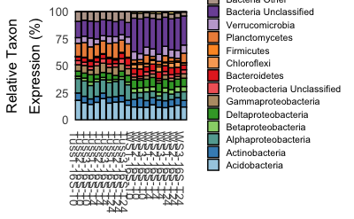

```r
taxa.16s.all.plot
```

#### 3.2.2 Mean Time Point

Plot the mean relative abundance of taxa by sampling time point within tussock and wet sedge tundra as a stackplot.

```r
# Place taxa in order for plotting
taxa.16s.time.mean.chart$Species<-factor(taxa.16s.time.mean.chart$Species,levels = c("Acidobacteria","Actinobacteria","Alphaproteobacteria","Betaproteobacteria","Deltaproteobacteria","Gammaproteobacteria","Proteobacteria Unclassified","Bacteroidetes","Chloroflexi","Firmicutes","Planctomycetes","Verrucomicrobia","Bacteria Unclassified","Bacteria Other","Archaea","Fungi"))

taxa.16s.time.mean.chart$Species<-fct_rev(taxa.16s.time.mean.chart$Species)

taxa.16s.time.mean.chart$Sample<-factor(taxa.16s.time.mean.chart$Sample,levels = c("Tuss-16S-T0","Tuss-16S-T4","Tuss-16S-T24","WS-16S-T0","WS-16S-T4","WS-16S-T24"))
```

```r
colourCount = length(unique(taxa.16s.time.mean.chart$Species))
getPalette = colorRampPalette(brewer.pal(12, "Paired"))

taxa.16s.time.mean.plot<-ggplot(taxa.16s.time.mean.chart, aes(fill=Species, y=Value, x=Sample)) + geom_bar(position = "stack", stat="identity", color="black") + ylab(expression(atop("Relative Taxon", paste("Expression (%)")))) + theme_minimal() + theme(axis.text=element_text(size=10),axis.title=element_text(size=12),axis.title.x=element_blank()) + theme(legend.position = "right", legend.title=element_blank(), legend.text=element_text(size=8), legend.key.size = unit(0.75,"line"), panel.background = element_blank(), panel.grid.major = element_blank(), panel.grid.minor = element_blank(), axis.line = element_blank(), panel.border = element_blank()) + scale_x_discrete(labels = function(Sample) str_wrap(Sample, width = 8)) + scale_size(guide=FALSE) + scale_fill_manual(values = rev(getPalette(colourCount))) + scale_x_discrete(labels = function(Sample) str_wrap(Sample, width = 15)) + theme(axis.text.x = element_text(angle = 270, hjust=0))
```

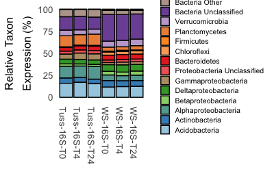

```r
taxa.16s.time.mean.plot
```

#### 3.2.3 Mean Tundra

Plot the mean relative abundance of taxa by within tussock and wet sedge tundra as a stackplot.

```r
# Place taxa in order for plotting
taxa.16s.tundra.mean.chart$Species<-factor(taxa.16s.tundra.mean.chart$Species,levels = c("Acidobacteria","Actinobacteria","Alphaproteobacteria","Betaproteobacteria","Deltaproteobacteria","Gammaproteobacteria","Proteobacteria Unclassified","Bacteroidetes","Chloroflexi","Firmicutes","Planctomycetes","Verrucomicrobia","Bacteria Unclassified","Bacteria Other","Archaea","Fungi"))

taxa.16s.tundra.mean.chart$Species<-fct_rev(taxa.16s.tundra.mean.chart$Species)

taxa.16s.tundra.mean.chart$Sample<-factor(taxa.16s.tundra.mean.chart$Sample,levels = c("Tuss-16S","WS-16S"))
```

```r
colourCount = length(unique(taxa.16s.tundra.mean.chart$Species))
getPalette = colorRampPalette(brewer.pal(12, "Paired"))

taxa.16s.tundra.mean.plot<-ggplot(taxa.16s.tundra.mean.chart, aes(fill=Species, y=Value, x=Sample)) + geom_bar(position = "stack", stat="identity", color="black") + ylab(expression(atop("Relative Taxon", paste("Expression (%)")))) + theme_minimal() + theme(axis.text=element_text(size=10),axis.title=element_text(size=12),axis.title.x=element_blank()) + theme(legend.position = "right", legend.title=element_blank(), legend.text=element_text(size=8), legend.key.size = unit(0.75,"line"), panel.background = element_blank(), panel.grid.major = element_blank(), panel.grid.minor = element_blank(), axis.line = element_blank(), panel.border = element_blank()) + scale_x_discrete(labels = function(Sample) str_wrap(Sample, width = 8)) + scale_size(guide=FALSE) + scale_fill_manual(values = rev(getPalette(colourCount))) + scale_x_discrete(labels = function(Sample) str_wrap(Sample, width = 15)) + theme(axis.text.x = element_text(angle = 270, hjust=0))
```

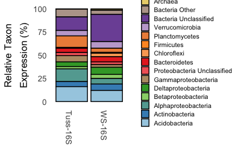

```r
taxa.16s.tundra.mean.plot
```

### 3.3 Taxonomy Statistics

To determine if there are significant differences in mean relative abundance of dominant taxa between tundra ecosystems, we calculate the mean (SD) of each phylum (dominant phylum; >1%) within tussock tundra and within wet sedge tundra throughout the experiment and compare to each other.

Test for differences in mean relative abundance of dominant phyla between tundra ecosystems.

```r
# Pairwise comparisons between tundra ecosystems for each microbial taxonomic class
taxa.16S.phylum.t.test.stats <- taxa.16S.phylum.t.test %>%
  group_by(Phylum) %>%
  pairwise_t_test(
    Abundance ~ Tundra, paired = TRUE,
    p.adjust.method = "bonferroni"
    ) %>%
  select(-.y., -n1, -n2, -df, -statistic, -p) # Remove details
taxa.16S.phylum.t.test.stats
```

| Phylum | group1 | group2 | p.adj | p.adj.signif |
| --- | --- | --- | --- | --- |
| Acidobacteria | Tuss | WS | 4.10e-02 | * |
| Actinobacteria | Tuss | WS | 2.15e-05 | **** |
| Alphaproteobacteria | Tuss | WS | 8.25e-06 | **** |
| Archaea Other | Tuss | WS | 1.00e-03 | ** |
| Bacteria Other | Tuss | WS | 2.34e-04 | *** |
| Bacteroidetes | Tuss | WS | 7.00e-03 | ** |
| Betaproteobacteria | Tuss | WS | 5.08e-07 | **** |
| Chloroflexi | Tuss | WS | 6.65e-05 | **** |
| Deltaproteobacteria | Tuss | WS | 2.52e-05 | **** |
| Euryarchaeota | Tuss | WS | 5.02e-04 | *** |

[output cut: 5 more lines]